# Anomaly detection in texts

Habidatum

August 5, 2016

### Objective

To identify Facebook posts in any given group whose semantic content deviates significantly from the average, or predominant, content of that group. This study reviews anomaly detection software that exists and demonstrates the accuracy of semantic fingerprinting, a method developed by [Cortical.io](http://www.cortical.io/). In a sample of Facebook posts extracted from the public group *Job Openings - Help for Freshers*, divergence from the statistical pattern and general semantic expectations will be defined according to various metrics.

### Background

The ability to detect anomalies in streams of text data is applicable in a broad range of scenarious, from fraudulent communication to organizational secuity. Usually, anomalies are detected by statistical comparison with typical data and subsequently evaluated by experts for the relevance. This is due to the fact that there very often many false positives.

Current statistical text analysis techniques implement tokenization- which is the act of breaking up a sequence of strings into smaller pieces such as keywords, phrases, symbols, words, etc. Tokens are useful for transforming data into generic categorical objects, but this results in the semantic content of the data being ignored. Several different techniques have been developed for uncovering unusual topics and words within a document corpus, and almost all rely on the content of the dataset being evaluated. For example, Guthrie et. al. [[1]](http://nlp.shef.ac.uk/Completed_PhD_Projects/guthrie.pdf) used an unsupervised learning technique that detects deviation in author, genre, topic, and tone of texts. Manevitz et al. [[2]](http://www.jmlr.org/papers/volume2/manevitz01a/manevitz01a.pdf) use an SVM methodology and neural networks to classify positive documents from negative ones. Srivastava et. al [3] have used various clustering algorithms such as k-means, spectral clustering, and Mises-Fisher to visualize and separate textual data. Mahapatra et al. [[4]](http://www.mdpi.com/1999-4893/5/4/469) exploit contextual information from external sources and used this as a post-processing step to improve and correct anomaly predictions.

### Anomaly Detection with SDR

Sparce Distributed Representations (SDR) are the way that humans process information, according to neuroscience research. [[5]](http://www.cortical.io/technology_representations.html) *Sparse* means that only some of many neurons are active at the same time. *Distributed* means that not only are the active cells spread across the representation, but the significance of the pattern is too. This makes the SDR resilient to the failure of single neurons and allows sub-sampling. As each bit or neuron has a meaning, if the same bit is active in two SDRs, it means that they are semantically similar.

The idea behind SDR as applied to language is based on converting the symbolic representation of language into a SDR form so that it becomes *numerically computable*. Language is first decomposed into its buildings blocks - words, then terms are then converted into SDRs. Every word is characterised by a bundle of 16,000 semantic features, that capture the lexical semantics of a word in its natural context. Two words become similar in their SDR form if they are conceptually related. Semantic similarity becomes directly commensurable even using a simple measure like the Euclidean Distance.

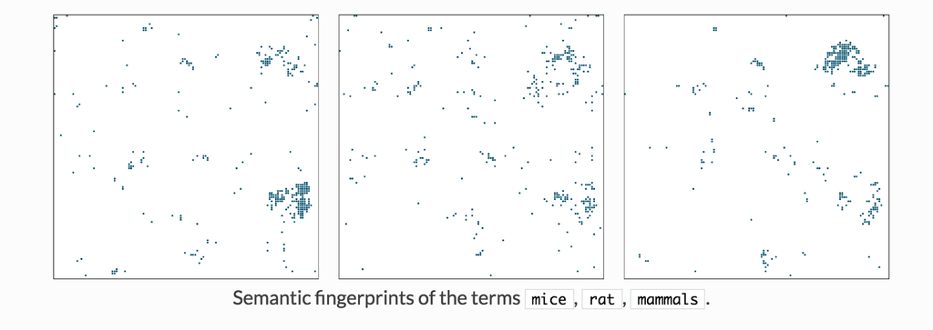

### Methodology

##### 1. Random sampling

In order to gather a representative sample of typical content from the Facebook group, 250 posts were downloaded using the `RFacebook` package. Sample posts were extracted between January and August 2016. Posts were then preprocessed: non-English posts were translated, punctuaion, URLS, non-alphanumeric symbology, and numbers were removed, whitespace was condenesed and the posts were then stiched together into one **corpus**. This served as the benchmark against which other posts would be compared using the Retina API.

##### 2. Known posts

The variable group consisted of posts collected between January 21-23. A manual review was conducted and the all posts were rated either neutral **N** or deviant **D**. Seven deviant posts were counted. In order to capture these posts and those around it, all posts that fell between January 21-23 were downloaded - a total of 193. In addition, content from 15 Twitter posts that negatively described situations with foreign workers - also rated as deviant messages - were added to the sample. This was done primarily to test the accuracy of the algorithm should such posts ever appear.

**Corpus**

```
##  chr "mega walking opening in cap Gemini position multiple our team provide best job in so get chance in just apply job and join with us qualification graduation apply here note we provide reference only our member so get membership here apply fast best of luck , breaking news bank clerk recruitm…
```

**Sampled posts**

```
## [1] "MEGA JOBS OPENING IN BIG MNC COMPANY Direct Interview and Immediate Joining Company VODAFONE Qualification Graduation Position Multiple Apply Here"
## [2] "LIC Recruitment Pay Scale Rs lakhs More Details"
## [3] "Software Developer Tech Pune jobsenz india"
## [4] "Mega jobs Opening in CAPITA INDIA POSITION Entry Level Our Team Provide Best Job in so get chance in just apply job and join with us Qualification Graduation Apply Here"
## [5] "Central Bank of India Recruitment Apply Online for Credit Officer Posts Last Date to Apply Online "
```

#### Workflow:

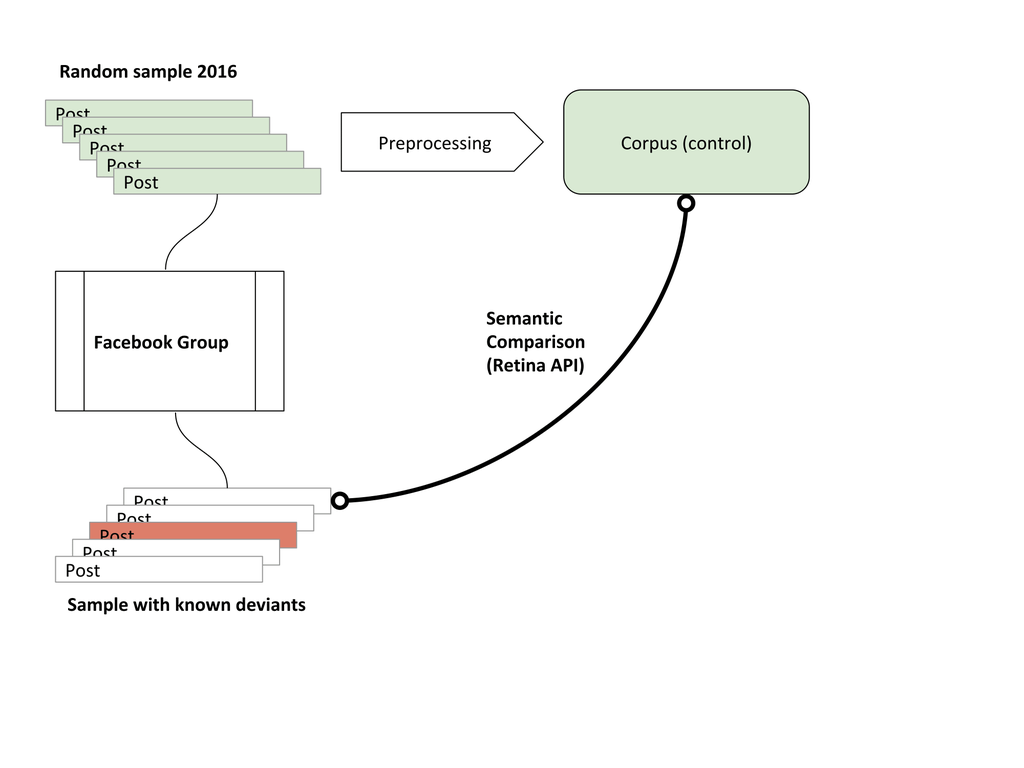

### Results

After inputting two text strings, the Compare API returns a `Metric` object that contains several similarity and distnance metrics. For example:

```r
{
  "jaccardDistance": 0.9224054316197866,
  "cosineSimilarity": 0.15886342635413125,
  "sizeLeft": 321,
  "overlappingAll": 80,
  "overlappingLeftRight": 0.24922118380062305,
  "overlappingRightLeft": 0.10126582278481013,
  "sizeRight": 790,
  "weightedScoring": 23.877803542783184,
  "euclideanDistance": 0.855985598559856
}
```

##### Cosine Similarity

Specifically cosine similarity is defined as a measure of similarity between two vectors of an inner product space that measures the cosine of the angle between them. Generally speaking the closer this value is to 1.0 the more similar the input terms are to each other.

##### Euclidean Distance

The Euclidean distance or Euclidean metric is the ordinary distance between two points that one would measure with a ruler. This means the closer this value is to 0.0 (zero), the closer the two items are with respect to similarity.

##### Jaccard Distance

The Jaccard distance, which measures dissimilarity between sample sets, is complementary to the Jaccard coefficient and is obtained by subtracting the Jaccard coefficient from 1.0. The closer the Jaccard distance is to 1.0 the more dissimilar the two items are.

##### Overlapping

When combined with the image view of a Semantic Fingerprint the overlapping positions enable a qualitative measure of similarity, in that it is then possible to identify the overlapping regions and to isolate the semantics of a particular region.

##### Weighted Scoring

This is a Cortical.io defined weighting for similarity measures. The higher the weighting, the more similar the terms. This measure can be used in one-to-many comparisons where one side of the comparison remains constant - for instance, an email filter, where the filter remains constant but is compared to many different emails.

The indeces used in this study were weighted scoring and euclidean distance. In the plot below, circles labeled **N** represent posts rated neutral, and **D** posts rated deviant. Deviant posts tend to have higher values of Euclidean distance (closer to 1) and lower values of weighted scores (closer to 0).

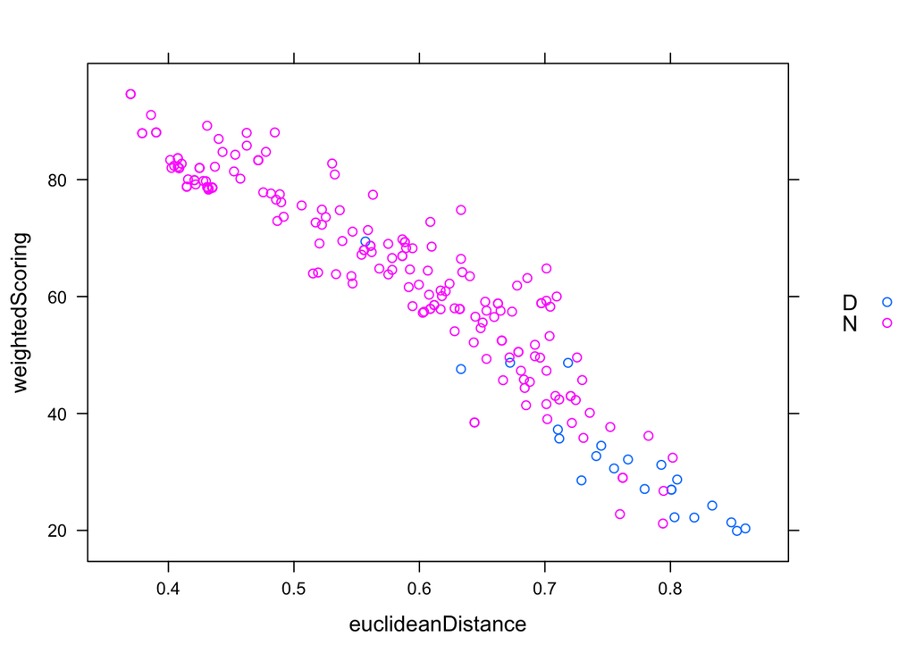

```r
sd(metrics$weightedScoring)
```

```
## [1] 18.44392
```

```r
aggregate(weightedScoring ~ rating, data = metrics, mean)
```

```
##   rating weightedScoring
## 1      D        32.58670
## 2      N        65.47901
```

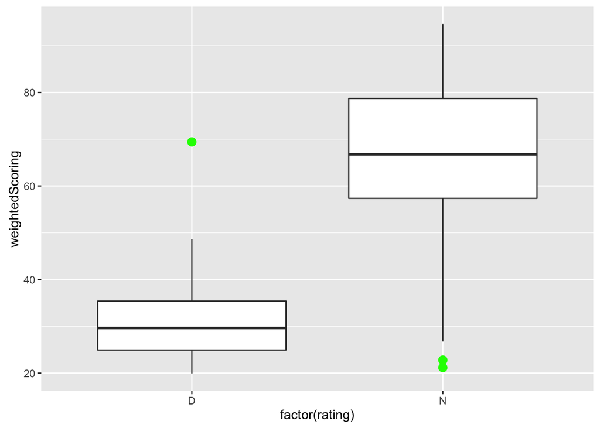

### Conclusion

If we use decide to use 2 standard deviations as the threshold below which posts should be inspected for deviance, we find that 3 out of 13 posts were classified as false positives, and 10 out of 13 were classified as true positives, giving our method an accuracy of **77%**

```
##
##  D  N
## 10  3
```